# R Notebook

```r
help(lag)
```

```r
library(astsa)
library(ggplot2)
```

```r
ts_ex1 <- soi
```

```r
ts_ex1_lag <- lag(ts_ex1, -6)
```

```r
sample_mean <- mean(ts_ex1)
sample_mean
```

```
[1] 0.08003753
```

```r
n <- length(ts_ex1)
```

# Calculate auto-covariance

```r
acov_ex1_h <- sum((ts_ex1_lag-sample_mean)*(ts_ex1-sample_mean))/n
acov_ex1_h
```

```
[1] -0.02733222
```

# Calculate auto-correlation

```r
acov_ex1_0 <- sum((ts_ex1-sample_mean)^2)/n
acov_ex1_0
```

```
[1] 0.1461714
```

```r
acor_ex1_h <- acov_ex1_h/acov_ex1_0
acor_ex1_h
```

```
[1] -0.1869874
```

Use “acf” function in R

```r
help(acf)
```

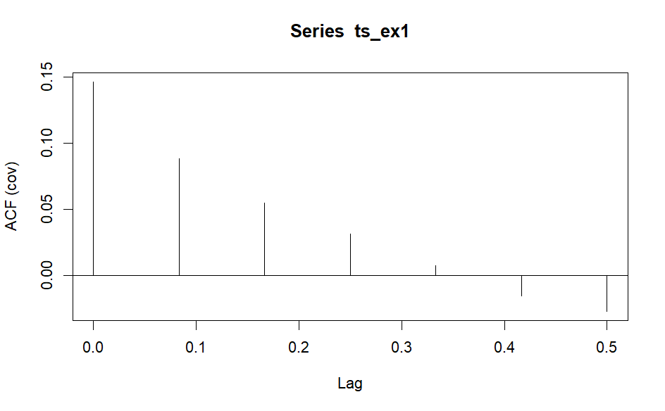

```r
acf(ts_ex1, lag.max = 6, type = "covariance")
```

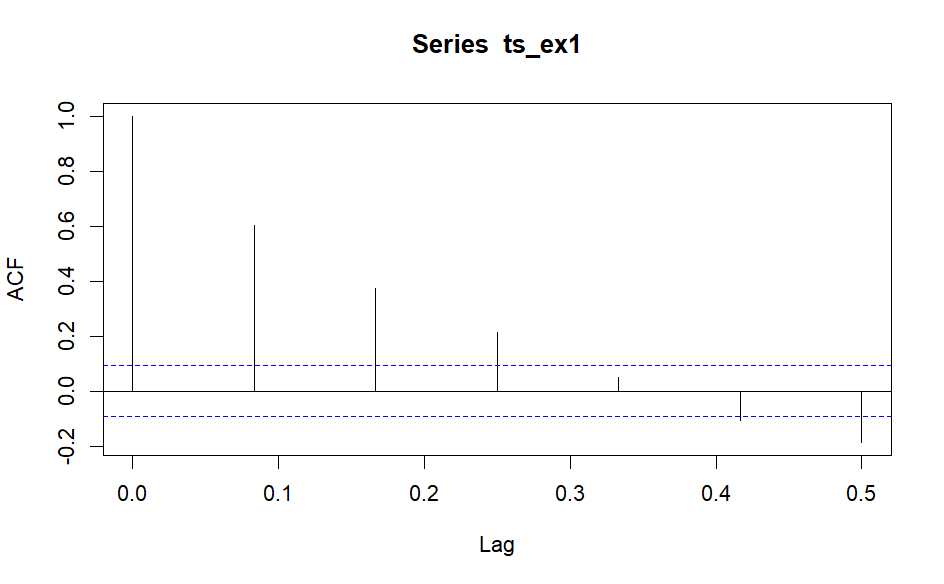

```r
acf(ts_ex1, lag.max=6, type = "correlation")
```

```r
li <- acf(ts_ex1, lag.max = 6, type = "correlation", plot = FALSE)
li
```

```
Autocorrelations of series ‘ts_ex1’, by lag

0.0000 0.0833 0.1667 0.2500 0.3333 0.4167 0.5000
 1.000  0.604  0.374  0.214  0.050 -0.107 -0.187
```

==> lag=6 là chỉ 6 tháng đầu, đơn vị thời gian của bộ dataset đang ghi theo năm => 1 tháng là 1/12 năm => tháng 1: 1/12 => tháng 2: 1/12*2 … => tháng 6: 1/12*6

```r
li$acf
```

```
, , 1

            [,1]
[1,]  1.00000000
[2,]  0.60410089
[3,]  0.37379533
[4,]  0.21412447
[5,]  0.05013659
[6,] -0.10703704
[7,] -0.18698742
```

```r
n <- length(ts_ex1)
n
```

```
[1] 453
```

```r
10*m<-2
```

```
Error in 10 * m <- 2 :
  target of assignment expands to non-language object
```

```r
10*log10((n-1)/m)
```

```
Error: object 'm' not found
```

# Question 1

Thực hiện lại Thí dụ 1 tính sample ACF và sample CCF cho SOI series St bằng hai cách • cách 1: tính trực tiếp theo công thức ước lượng lý thuyết; • cách 2: sử dụng hàm acf(…); nhưng với giá trị “lag parameter h” lần lượt là h = 5, h = 2, h = −3.

```r
li <- c(5, 2, -3)
sample_mean <- mean(ts_ex1)
n <- length(ts_ex1)
acov_0 <- sum((ts_ex1-sample_mean)^2)/n
for (h in li){
  ts_lag <- lag(ts_ex1, -h)
  acov_h <- sum((ts_lag-sample_mean)*(ts_ex1-sample_mean))/n
  acor_h <- acov_h/acov_0
  print(paste0('Với h = ', h, ' acov là: ', acov_h, ' và acor là ', acor_h))
}
```

[output not shown]

```r
li <- c(5, 2, -3)
for (h in li){
  acov <- acf(ts_ex1, lag.max = abs(h), type='covariance', plot=FALSE)
  acor <- acf(ts_ex1, lag.max = abs(h), type='correlation', plot=FALSE)
  print(paste0('Với h = ', h))
  print('acov')
  print(acov$acf)
  print('acor')
  print(acor$acf)
}
```

[output not shown]

```r
help(ccf)
```

# Bài tập 2

Bài 2. (a) Mô phỏng một realization (hay sample) của Gaussian white noise time series Wt cỡ mẫu n = 500 với σW = 1.2. Sau đó, tính sample autocovariance function γbW (h) và sample auto-correlation function (ACF) ρbW (h) của dữ liệu mô phỏng này, với “lag = 20”. So sánh giá trị ước lượng sample ACF với giá trị chính xác theo lý thuyết (xem lại thí dụ đã tính hàm ACF ρ(h) cho gaussian white noise). (b) Thực hiện lại câu (a) nhưng với cỡ mẫu n = 50. Qua đó đưa ra nhận xét xem cỡ mẫu có ảnh hưởng gì đến kết quả tính toán hay không?

```r
t <- 0:500
n <- length(t)
data <- rnorm(n, sd=1.2)
```

```r
plot(t, data, type='l')
```

[output not shown]

```r
ts_data <- ts(data)
```

```r
acf(ts_data, lag.max = 20, type='covariance', plot = TRUE)
```

[output not shown]

```r
acf(ts_data, lag.max = 20, type='covariance', plot=FALSE)
```

[output not shown]

```r
acf(ts_data, lag.max = 20, type='correlation', plot = TRUE)
```

[output not shown]

```r
acf(ts_data, lag.max = 20, type='correlation', plot = FALSE)
```

[output not shown]

# Bộ data chicken

```r
data <- chicken
```

```r
t <- time(chicken)
```

```r
model <- lm(data~t)
model$coefficients
```

[output not shown]

```r
df <- data.frame(time = t, price=data)
```

```r
plot(df, type='l')
```

[output not shown]

```r
Xt <- model$coefficients[1] + model$coefficients[2]*t
plot(Xt)
```

[output not shown]

# BỘ dữ liệu population

```r
pairs(cbind(tempr, part, cmort))
```

[output not shown]

```r
model <- lm(cmort~time(cmort) + part+tempr)
summary(model)
```

[output not shown]